# MATH 2310 Lab 2

## Problems to Submit

### Section 1 Intro

In this section you will use some sample data and guess/estimate what the underlying distribution is based on properties of the sample. This is a fundamental concept in statistics and there are many advanced ways to answer these kinds of problems. However for the purpose of this problem, you will just use a histogram and what you know of the families of distributions we have discussed to estimate/make an educated guess what the family and parameters are.

### Section 1 Import Data

Adjust your path as necessary. The data set contains a single column of data which represent temperature measurements.

```r
df= read.csv('DailyTemp.csv',fileEncoding="UTF-8-BOM")
```

### Section 1 Question 1

**Create a histogram of the temperature values on the density scale, select the bins so that the shape of the distribution is highlighted. Show a list of the boundary values of your bins.**

#### Answer

```r
# Use to calculate the bin widths or bin numbers
S1Q1_bins = round(sqrt(length(df$temp)))
S1Q1_bins
```

```
## [1] 63
```

```r
#use the seq function to display the endpoints of your bins
S1Q1_min = min(df$temp)
S1Q1_max = max(df$temp)
seq(S1Q1_min, S1Q1_max, (S1Q1_max - S1Q1_min)/S1Q1_bins) # is there a better way to do this?
```

```
##  [1] 17.63732 18.74980 19.86228 20.97475 22.08723 23.19971 24.31219 25.42467
##  [9] 26.53715 27.64962 28.76210 29.87458 30.98706 32.09954 33.21202 34.32450
## [17] 35.43697 36.54945 37.66193 38.77441 39.88689 40.99937 42.11184 43.22432
## [25] 44.33680 45.44928 46.56176 47.67424 48.78671 49.89919 51.01167 52.12415
## [33] 53.23663 54.34911 55.46159 56.57406 57.68654 58.79902 59.91150 61.02398
## [41] 62.13646 63.24893 64.36141 65.47389 66.58637 67.69885 68.81133 69.92380
## [49] 71.03628 72.14876 73.26124 74.37372 75.48620 76.59868 77.71115 78.82363
## [57] 79.93611 81.04859 82.16107 83.27355 84.38602 85.49850 86.61098 87.72346
```

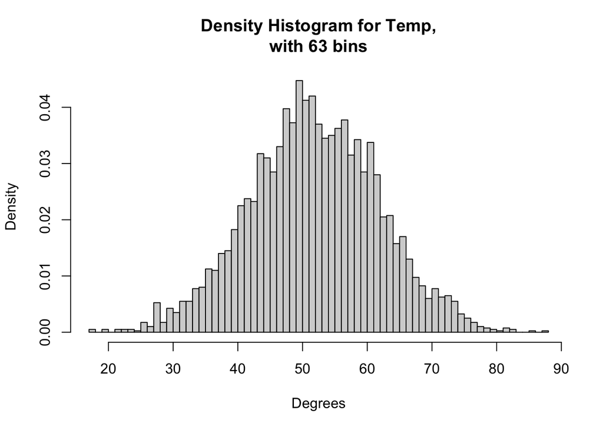

```r
# Build your histogram
hist(df$temp, breaks = S1Q1_bins, freq=FALSE,main= paste('Density Histogram for Temp,\nwith', S1Q1_bins, 'bins'), xlab = "Degrees")
```

By using the `sqrt` of num entires formula, I am able to determine the best number of bins. Afterwards, that information is provided to the `hist` function to render a density histogram of the `Temp` column.

### Section 1 Question 2

**Describe the shape of the histogram in words.**

#### Answer

This histogram is single modal and appears to be fairly symetrical. It seems to be a normal distribution.

### Section 1 Question 3

**There are sophisticated ways of testing if certain families are appropriate for a given sample and we will talk about some later in the course. For now, I want you to use what you know about the shapes of density functions to make an educated guess as to which family of distributions the data comes from. State what your guess is and why.**

#### Answer

**Normal distribution**! I believe this is a normal distribution because the histogram is fairly uniform and symmetrical. The placement of the data follows a “bell curve”.

### Section 1 Question 4

**There are some sophisticated mathematical techniques we will explore later to determine parameters for a family to best fit some sample data that potentially came from that distribution. However, in this case there are some simple ways of coming up with what the parameters might be (think about what the names of the parameters are for the family you have chosen). Use what you know to come up with potential parameters for the underlying distribution. There are some built in functions in R that you can look up that might be helpful. (mean and sd are functions that might be helpful)**

#### Answer

```r
S1Q4_mean = mean(df$temp)
S1Q4_sd = sd(df$temp)

paste("Mean:", S1Q4_mean)
```

```
## [1] "Mean: 51.8001717533225"
```

```r
paste("Standard Deviation:", S1Q4_sd)
```

```
## [1] "Standard Deviation: 9.97236580120777"
```

By using the `mean` and `sd` functions, we can easily calculate the mean and standard deviation of the *temp* data. Both **mean** and **standard deviation** serve as parameters to a normal distribution.

### Section 1 Question 5

**Using the estimated parameters calculated in the previous question. re-plot the histogram of the sample data but now add the curve of the density function for the distribution you decided on overlayed on top of the histogram. Does the curve fit your data? If not why?**

#### Answer

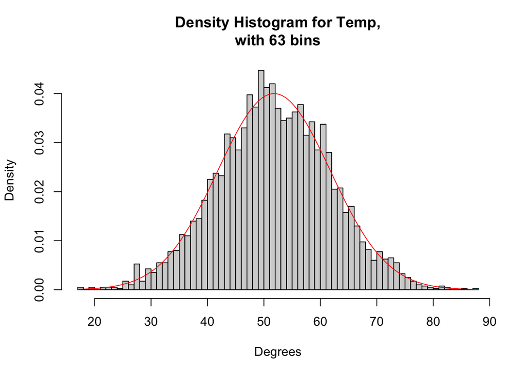

```r
#Make your histogram and the density function
hist(df$temp, breaks = S1Q1_bins, freq=FALSE,main= paste('Density Histogram for Temp,\nwith', S1Q1_bins, 'bins'), xlab = "Degrees")
curve(dnorm(x, mean=S1Q4_mean, sd=S1Q4_sd), col='red', add=TRUE)
```

Tada! The normal distribution which is overlayed on top of the previous histogram closely fits the data. The curve run very close to the bars.

### Section 2 Intro

**In this problem you will use the built in functions to answer some questions about a Poisson Process.**

**Suppose that on average a certain store serves 15 customers per hour during their hours of operation. Assume that all assumptions of a Poisson Process hold. Use the built in functions to answer the following question.**

**When answering the questions**

- **State clearly in words the random variable you are considering, what the parameters are and how the question translates into a statement about the probability of that variable.**
- **Show the calculations to evaluate the probability.**
- **State in words what the final answer is.**

### Section 2 Question 1

**What is the probability that the store swill serve between 10 and 20 customers (inclusive) in a particular 2 hour period?**

- State the random variable you would use in words

  $X = \text{The store serving between 10 and 20 customers (inclusive) in a 2 hour period}$
- State the type of random variable and the parameters.

  Poission distribution.

  $\lambda = 15 \times 2 = 30$ (Average number of customers in a 2 hour period)
- State the probability you want to compute.

#### Answer

```r
# Put your calculations here.
S2Q1_lambda = 15*2 # 15/hour * 2 hours
ppois(20, S2Q1_lambda) - ppois(10-1, S2Q1_lambda) # Minus 1 because it's inclusive
```

```
## [1] 0.0352775
```

There is a 3% chance that the store will serve between 10 and 20 customers (inclusive) within a 2 hour period.

### Section 2 Question 2

**At noon, the shop owner wonders how long it will be until the next customer arrives. What is the probability that the next customer will arrive in less than 3 minutes?**

- State the random variable you would use in words

  $X = \text{Time until the next customer arrives}$
- State the type of random variable and the parameters.

  Exponential.

  $\lambda = 15$
- State the probability you want to compute.

  $P(x < \dfrac{3}{60})$

  $\frac{3}{60}$ because that is 3 minutes represented in hours.
- Use the built in functions to calculate that probability.
- State clearly what the final answer is in words.

#### Answer

```r
S2Q1_lambda = 15
pexp(3/60, rate=S2Q1_lambda)
```

```
## [1] 0.5276334
```

The chance that the next customer will arrive in less than 3 minutes is $52.76\%$.

### Section 3 Intro

**In this problem you will use the built in functions to answer some questions that combine two types of random variables.**

**Suppose that you know that a certain chemical process releases H20 as one of the outputs. Each time the process is run the amount of H20 in ml is known to follow a normal distribution with mean 20 and standard deviation of 2. Additionally, the processes is considered defective if either more than 21.2 ml is released or if less than 18.6 ml is released.**

### Section 3 Question 1

**What is the probability that when the process is run once that it will not be considered defective?**

- State the random variable you would use in words

  Normal Distribution

  $\text{mean} = 20\\ \text{sd} = 2$
- State the probability you want to compute.

#### Answer

```r
S3Q1_mean = 20
S3Q1_sd = 2
S3Q1_output = pnorm(21.2, S3Q1_mean, S3Q1_sd) - pnorm(18.6, S3Q1_mean, S3Q1_sd)
S3Q1_output
```

```
## [1] 0.4837832
```

From a single run, there is a $48.38\%$ chance that the process was not defective.

### Section 3 Question 2

**Suppose that the process is run 365 times (once each day for a year). What is the probability that there will be at least 160 successful runs of the process. Hint - be careful about < vs <= with discrete distributions**

- State the random variable you would use in words

  $X = \text{at least 160 of 365 runs are successful}$
- State the type of random variable and the parameters.

  Binomial Distribution.

  $n = 365\\ \pi = 0.4837832$ (This was calculated above as a part of Section 3, Question 1)
- State the probability you want to compute.

  $P(X \ge 160)$
- Use the built in functions to calculate that probability.
- State clearly what the final answer is in words.

#### Answer

```r
S3Q2_n = 365
S3Q2_pi = S3Q1_output

1 - pbinom(160-1, S3Q2_n, S3Q2_pi)
```

```
## [1] 0.9633699
```

There is a $96.34\%$ chance that at least 160 of 365 runs are successful.